# TFM — Gastronomía asiática en Europa

## Semana 2: Análisis Exploratorio de Datos (EDA)

Partimos del subconjunto filtrado en la Semana 1 (`asian_restaurants_europe.csv`).

- 3.1 Distribución geográfica de restaurantes asiáticos en Europa
- 3.2 Tipos de cocina asiática predominantes por país
- 3.3 Análisis de valoraciones y reseñas
- Identificación de variables relevantes para el modelo

## 0. Setup

```python
%matplotlib inline
import pandas as pd
import numpy as np
import matplotlib.pyplot as plt
import seaborn as sns
import plotly.express as px
import warnings

warnings.filterwarnings('ignore')
sns.set_style('whitegrid')
pd.set_option('display.max_columns', 50)

df = pd.read_csv('../data/asian_restaurants_europe.csv', low_memory=False)
print('Shape:', df.shape)
df.head()
```

```
Shape: (86306, 42)
```

|  | restaurant_link | restaurant_name | original_location | country | region | province | city | address | latitude | longitude | claimed | awards | popularity_detailed | popularity_generic | top_tags | price_level | price_range | meals | cuisines | special_diets | features | vegetarian_friendly | vegan_options | gluten_free | original_open_hours | open_days_per_week | open_hours_per_week | working_shifts_per_week | avg_rating | … |
| --- | --- | --- | --- | --- | --- | --- | --- | --- | --- | --- | --- | --- | --- | --- | --- | --- | --- | --- | --- | --- | --- | --- | --- | --- | --- | --- | --- | --- | --- | --- |
| 0 | g1005749-d14139205 | Angkor | ["Europe", "France", "Provence-Alpes-Cote d'Az... | France | Provence-Alpes-Cote d'Azur | Var | Rocbaron | Lieu-dit Fray Redon Zac Du Frey Redon, 83136 R... | 43.315370 | 6.076720 | Unclaimed | NaN | #10 of 10 Restaurants in Rocbaron | #10 of 12 places to eat in Rocbaron | Chinese, Japanese | NaN | NaN | NaN | Chinese, Japanese | NaN | NaN | N | N | N | NaN | NaN | NaN | NaN | 3.5 | … |
| 1 | g1005749-d6403874 | Esprit Sushi Rocbaron | ["Europe", "France", "Provence-Alpes-Cote d'Az... | France | Provence-Alpes-Cote d'Azur | Var | Rocbaron | 2 Zac de Fray Redon, 83136 Rocbaron France | 43.315327 | 6.075969 | Claimed | Certificate of Excellence 2016 | #6 of 10 Restaurants in Rocbaron | #6 of 12 places to eat in Rocbaron | Mid-range, Japanese, Sushi, Asian | €€-€€€ | NaN | Lunch, Dinner, After-hours | Japanese, Sushi, Asian | NaN | Delivery, Takeout, Reservations, Seating, Whee... | N | N | N | {"Mon": ["11:30-14:00", "17:00-22:00"], "Tue":... | 7.0 | 52.5 | 14.0 | 4.0 | … |
| 2 | g1005948-d21134003 | L'atelier des Saveurs | ["Europe", "France", "Auvergne-Rhone-Alpes", "... | France | Auvergne-Rhone-Alpes | Savoie | Lanslebourg Mont Cenis | 31 rue du Mont Cenis, 73480 Lanslebourg Mont C... | 45.285313 | 6.876601 | Claimed | NaN | #19 of 28 places to eat in Lanslebourg Mont Cenis | NaN | Mid-range, Delivery Only, French, European | €€-€€€ | €9-€25 | Lunch, Breakfast, Dinner, Drinks | European, Asian, Thai, Vietnamese, French | NaN | NaN | N | N | N | {"Mon": ["07:30-21:00"], "Tue": ["07:30-21:00"... | 7.0 | 95.5 | 7.0 | 5.0 | … |
| 3 | g10060888-d14922293 | Wafu | ["Europe", "France", "Hauts-de-France", "Somme... | France | Hauts-de-France | Somme | Meaulte | Au Chemin Croisé, 80300 Meaulte France | 49.991180 | 2.658770 | Unclaimed | NaN | #1 of 1 Restaurant in Meaulte | #1 of 1 places to eat in Meaulte | Mid-range, Chinese, Japanese, Asian | €€-€€€ | NaN | Lunch, Dinner | Asian, Chinese, Japanese, Vietnamese | NaN | Takeout, Reservations, Seating, Wheelchair Acc... | N | N | N | NaN | NaN | NaN | NaN | 4.0 | … |
| 4 | g1006520-d1017687 | Little Tokyo | ["Europe", "France", "Ile-de-France", "Yveline... | France | Ile-de-France | Yvelines | Conflans Sainte Honorine | 2 boulevard Troussel, 78700 Conflans Sainte Ho... | 48.990112 | 2.082339 | Unclaimed | Certificate of Excellence 2016, Certificate of... | #13 of 64 Restaurants in Conflans Sainte Honorine | #13 of 68 places to eat in Conflans Sainte Hon... | Mid-range, Japanese, Sushi, Asian | €€-€€€ | NaN | Lunch, Dinner | Japanese, Sushi, Asian | Vegetarian Friendly | NaN | Y | N | N | {"Mon": ["11:30-02:30"], "Tue": ["11:30-02:30"... | 7.0 | 105.0 | 7.0 | 4.0 | … |

## 3.1 Distribución geográfica de restaurantes asiáticos en Europa

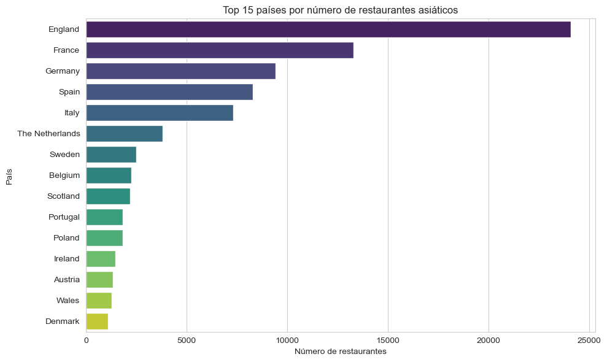

```python
top_countries = df['country'].value_counts().head(15)

plt.figure(figsize=(10, 6))
sns.barplot(x=top_countries.values, y=top_countries.index, hue=top_countries.index, palette='viridis', legend=False)
plt.title('Top 15 países por número de restaurantes asiáticos')
plt.xlabel('Número de restaurantes')
plt.ylabel('País')
plt.tight_layout()
plt.savefig('../data/fig_top_countries.png', dpi=100)
plt.show()
```

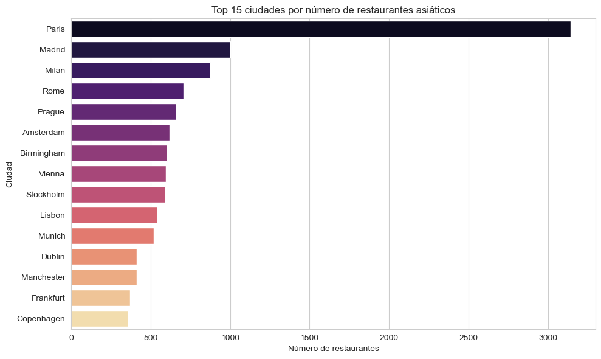

```python
top_cities = df['city'].value_counts().head(15)

plt.figure(figsize=(10, 6))
sns.barplot(x=top_cities.values, y=top_cities.index, hue=top_cities.index, palette='magma', legend=False)
plt.title('Top 15 ciudades por número de restaurantes asiáticos')
plt.xlabel('Número de restaurantes')
plt.ylabel('Ciudad')
plt.tight_layout()
plt.savefig('../data/fig_top_cities.png', dpi=100)
plt.show()
```

### Foco en España

```python
df_spain = df[df['country'] == 'Spain']
print(f"Restaurantes asiáticos en España: {len(df_spain)}")
df_spain['city'].value_counts().head(10)
```

```
Restaurantes asiáticos en España: 8295
```

```
city
Madrid                        1000
Palma de Mallorca              218
Las Palmas de Gran Canaria     108
Murcia                          68
Santa Cruz de Tenerife          54
Playa de las Americas           50
Puerto Del Carmen               40
Los Cristianos                  39
Playa del Ingles                38
Tenerife                        37
Name: count, dtype: int64
```

## 3.2 Tipos de cocina asiática predominantes por país

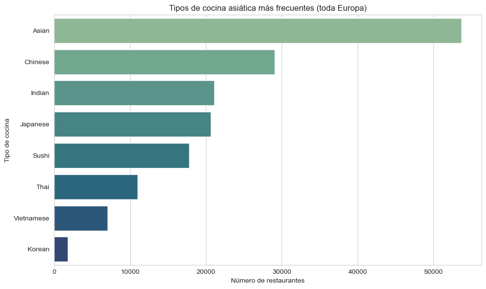

```python
asian_cuisines = ['Chinese', 'Japanese', 'Thai', 'Korean',
                  'Vietnamese', 'Indian', 'Asian', 'Sushi',
                  'Dim Sum', 'Ramen', 'Noodles']

def extract_asian(cell):
    if pd.isna(cell):
        return []
    parts = [p.strip() for p in cell.split(',')]
    return [p for p in parts if p.lower() in [a.lower() for a in asian_cuisines]]

df['asian_cuisine_list'] = df['cuisines'].apply(extract_asian)

exploded = df[['country', 'asian_cuisine_list']].explode('asian_cuisine_list').dropna(subset=['asian_cuisine_list'])
cuisine_counts = exploded['asian_cuisine_list'].value_counts()

plt.figure(figsize=(10, 6))
sns.barplot(x=cuisine_counts.values, y=cuisine_counts.index, hue=cuisine_counts.index, palette='crest', legend=False)
plt.title('Tipos de cocina asiática más frecuentes (toda Europa)')
plt.xlabel('Número de restaurantes')
plt.ylabel('Tipo de cocina')
plt.tight_layout()
plt.savefig('../data/fig_cuisine_types.png', dpi=100)
plt.show()
```

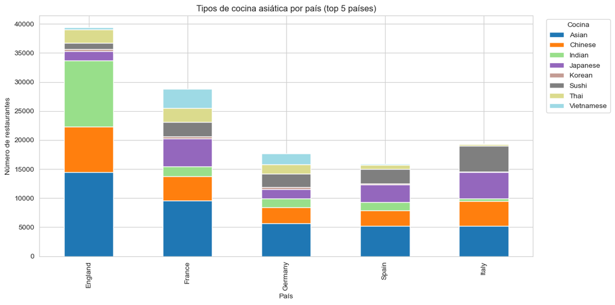

```python
top5_countries = df['country'].value_counts().head(5).index.tolist()
sub = exploded[exploded['country'].isin(top5_countries)]

pivot = pd.crosstab(sub['country'], sub['asian_cuisine_list'])
pivot = pivot.loc[top5_countries]

pivot.plot(kind='bar', stacked=True, figsize=(12, 6), colormap='tab20')
plt.title('Tipos de cocina asiática por país (top 5 países)')
plt.xlabel('País')
plt.ylabel('Número de restaurantes')
plt.legend(title='Cocina', bbox_to_anchor=(1.02, 1), loc='upper left')
plt.tight_layout()
plt.savefig('../data/fig_cuisine_by_country.png', dpi=100)
plt.show()
```

## Mapa geográfico de restaurantes asiáticos en Europa

```python
df_map = df.dropna(subset=['latitude', 'longitude']).copy()

fig = px.scatter_geo(
    df_map,
    lat='latitude',
    lon='longitude',
    color='country',
    hover_name='restaurant_name',
    hover_data=['city', 'avg_rating'],
    scope='europe',
    title=f'Restaurantes asiáticos en Europa (n={len(df_map)})',
    opacity=0.5,
)
fig.update_layout(height=700, showlegend=False)
fig.write_html('../data/mapa_restaurantes_asiaticos.html')
fig.show()
```

[interactive chart not shown]

## 3.3 Análisis de valoraciones (ratings) y número de reseñas

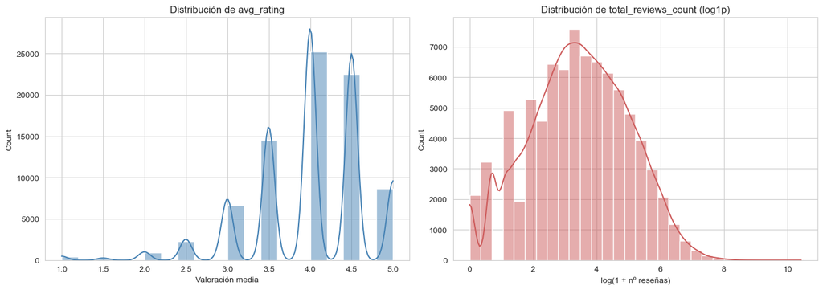

```
count    81315.000000
mean         3.986306
std          0.688331
min          1.000000
25%          3.500000
50%          4.000000
75%          4.500000
max          5.000000
Name: avg_rating, dtype: float64
```

```python
fig, axes = plt.subplots(1, 2, figsize=(14, 5))

sns.histplot(df['avg_rating'].dropna(), bins=20, kde=True, ax=axes[0], color='steelblue')
axes[0].set_title('Distribución de avg_rating')
axes[0].set_xlabel('Valoración media')

sns.histplot(np.log1p(df['total_reviews_count'].dropna()), bins=30, kde=True, ax=axes[1], color='indianred')
axes[1].set_title('Distribución de total_reviews_count (log1p)')
axes[1].set_xlabel('log(1 + nº reseñas)')

plt.tight_layout()
plt.savefig('../data/fig_ratings_reviews_dist.png', dpi=100)
plt.show()

print(df['avg_rating'].describe())
```

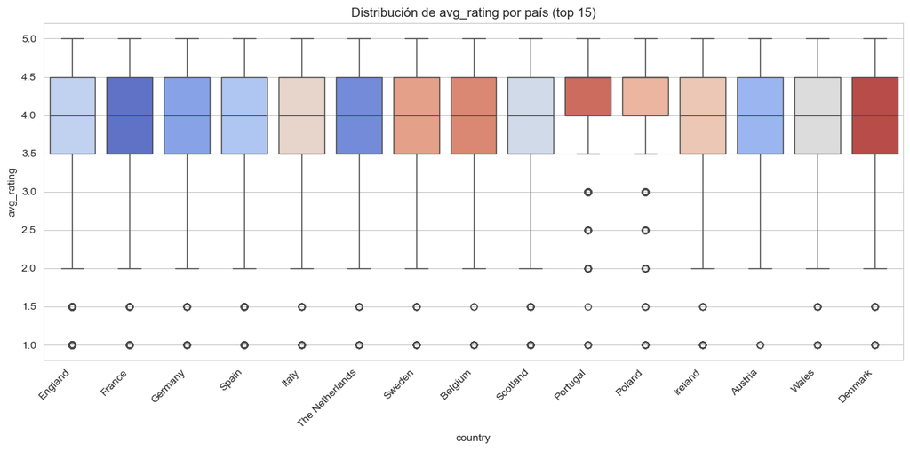

```python
plt.figure(figsize=(12, 6))
order = df.groupby('country')['avg_rating'].median().sort_values(ascending=False).loc[top_countries.index]
sns.boxplot(data=df[df['country'].isin(top_countries.index)], x='country', y='avg_rating',
            order=order.index, hue='country', palette='coolwarm', legend=False)
plt.xticks(rotation=45, ha='right')
plt.title('Distribución de avg_rating por país (top 15)')
plt.tight_layout()
plt.savefig('../data/fig_rating_by_country.png', dpi=100)
plt.show()
```

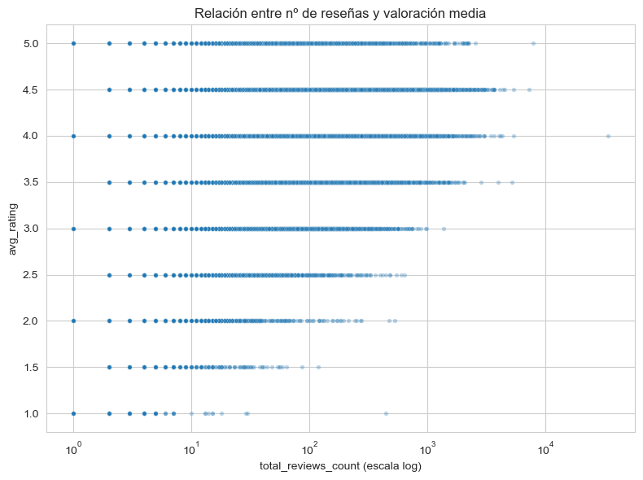

```
Correlación (Pearson) reviews vs rating: 0.077
```

```python
plt.figure(figsize=(8, 6))
sns.scatterplot(data=df, x='total_reviews_count', y='avg_rating', alpha=0.3, s=15)
plt.xscale('log')
plt.title('Relación entre nº de reseñas y valoración media')
plt.xlabel('total_reviews_count (escala log)')
plt.ylabel('avg_rating')
plt.tight_layout()
plt.savefig('../data/fig_reviews_vs_rating.png', dpi=100)
plt.show()

corr = df['total_reviews_count'].corr(df['avg_rating'])
print(f'Correlación (Pearson) reviews vs rating: {corr:.3f}')
```

## Identificación de variables relevantes para el modelo

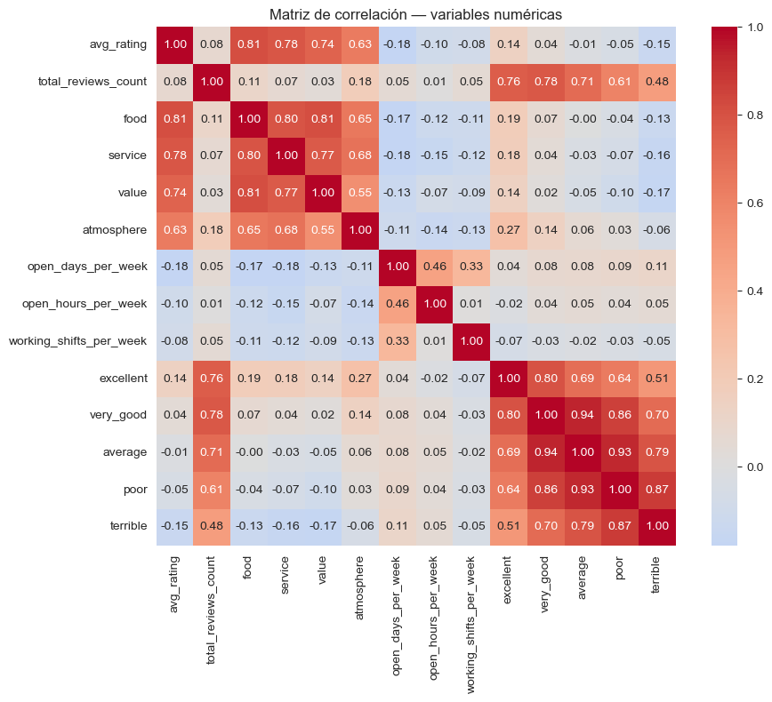

```python
numeric_cols = ['avg_rating', 'total_reviews_count', 'food', 'service', 'value', 'atmosphere',
                'open_days_per_week', 'open_hours_per_week', 'working_shifts_per_week',
                'excellent', 'very_good', 'average', 'poor', 'terrible']

corr_matrix = df[numeric_cols].corr()

plt.figure(figsize=(10, 8))
sns.heatmap(corr_matrix, annot=True, fmt='.2f', cmap='coolwarm', center=0, square=True)
plt.title('Matriz de correlación — variables numéricas')
plt.tight_layout()
plt.savefig('../data/fig_correlation_matrix.png', dpi=100)
plt.show()
```

```python
corr_matrix['avg_rating'].drop('avg_rating').sort_values(key=abs, ascending=False)
```

```
food                       0.811573
service                    0.781414
value                      0.741447
atmosphere                 0.634868
open_days_per_week        -0.179478
terrible                  -0.145534
excellent                  0.144164
open_hours_per_week       -0.096734
working_shifts_per_week   -0.084615
total_reviews_count        0.077184
poor                      -0.051070
very_good                  0.044336
average                   -0.014687
Name: avg_rating, dtype: float64
```

### Conclusiones preliminares (Semana 2)

- **Geografía:** Reino Unido, Francia y Alemania concentran la mayor oferta de restaurantes asiáticos; España se sitúa entre los países con mayor presencia.
- **Cocinas:** conviene revisar el gráfico de tipos de cocina para identificar si "Asian" genérico domina sobre categorías específicas (China, India, Japón...).
- **Ratings:** la mayoría de restaurantes se agrupa en valoraciones altas (sesgo típico de TripAdvisor); la correlación entre nº de reseñas y rating es débil.
- **Variables candidatas para el modelo:** `food`, `service`, `value`, `atmosphere` muestran las mayores correlaciones con `avg_rating` — serán prioritarias en el feature engineering de la Semana 3. `excellent`/`very_good`/`poor`/`terrible` son en realidad conteos derivados del propio rating y deben tratarse con cuidado (fuga de información / leakage) al construir el modelo predictivo.